# Deliverable 3

Kyle Kirk

We will work on the third deliverable, but to do so we need to bring in everything from the first and second. We can do this in the same fashion that we did in the previous deliverable by incorporating everything from the second.

After the peer review we did in class on 10/05, Reese Tresendez had this to say :

## **Data Preparation:**

The data was well organized and I there was emphasis multiple times with constant renaming of variables to keep the flow consistent and easy to follow. Overall very well done!

## **Modeling:**

The overall flow of modeling in this deliverable is very well done. The coloring looks nice and the graphs display exactly what I expected to see based on the explanation. My only suggestion within this section would be to print out less of the data as the actual data points are not as necessary as the visualization from a graph is what is important.

## **R Proficiency:**

From what I saw it seems like there was a lot of thought put into how to manipulate the data to make it work as intended. I have worked with this data set before and your use of R functions to make it manageable was very well done!

## **Communication:**

There was a lot of small R blocks which were each explained in at least one sentence which made it very easy to follow the flow of the project. I would say the communication was almost over the top. Overall very well done, my only suggestion would be to lump more code together and give the same amount of detail when explaining a block as opposed to more of a single line.

## **Critical Thinking:**

I believe that this project reflects your goal very well and I believe that based on the language alone that there was a lot of time put into this. You seemed to really understand the dataset and what it is providing and the overall results while may not have proved to be a correlation was very well presented.

## **Summary:**

This was a really good deliverable that seemed to very nicely build off of your first part. I would suggest for the future keep doing what you are doing and maybe look into the correlation between job opportunities and employment. This might be useful in figuring out if the region is part of the limitations or is effecting the results.

## Rework

Given the information returned from Reese, I decided to follow his suggestions. I’ve adjusted the second deliverable to combine more chunks of code and combine the explanations together.

The concept of job opportunities and employment is a good one, and that will require another dataset. There is no solid statistic on open jobs county by county, or United states, but we had a third dataset in the second deliverables. This may be the opportunity to focus on it more, there is a dataset from National Center for (Education Statistics)[https://nces.ed.gov/programs/digest/d18/tables/dt18_104.20.asp]

We will clean the data after taking it, turn it into a tibble. We’ll take only the data from combined male/female ratio’s. We’ll change the names of the columns into human readable forms, and split them by the racial categories in the excel spreadsheet. We’ll also be adding a US Average column.

```r
County_Education <- read_excel("Education2.xls")
```

```
## * `` -> ...3
## * `` -> ...4
## * `` -> ...6
## * `` -> ...7
## * `` -> ...9
## * … and 15 more problems
```

```r
County_Education <- as_tibble(County_Education)
County_Education <- select(County_Education, 1, 5, 8, 11, 17, 20, 23, 26)
colnames(County_Education)[colnames(County_Education) == "Sex, selected level of educational attainment, and year"] <- "year"

colnames(County_Education)[2] <- "white"
colnames(County_Education)[3] <- "black"
colnames(County_Education)[4] <- "hispanic"
colnames(County_Education)[5] <- "asian"
colnames(County_Education)[6] <- "pac_islander"
colnames(County_Education)[7] <- "indigenous"
colnames(County_Education)[8] <- "two_plus"
newCountyData <- subset(County_Education, !is.na(year))
newCountyData[, 2:8] <- sapply(newCountyData[,2:8], as.numeric)
newCountyData <- newCountyData %>%
  replace(is.na(.), 0) %>%
  mutate(total = rowSums(.[2:8])/7)
edu_levels_raw <- newCountyData[3:60, c(1,9)]
df2 <- edu_levels_raw %>%
  mutate(year = str_remove_all(year, "\\.(?!\\d{2,}$)") %>%
           str_replace_all(",", "."))
```

The data has been cleaned, but we still need to do more. While the values are more readable, we do need to separate it so that we can do some linear regression models on it.

```r
df2$year <- as.numeric(df2$year)
highschool_edu <- df2[2:15, 1:2]
add_column(highschool_edu, edu_level = "HS or more.", .after = "year")
```

| year | edu_level | total |
| --- | --- | --- |
| 2005 | HS or more. | 87.09267 |
| 2006 | HS or more. | 85.99203 |
| 2007 | HS or more. | 86.39480 |
| 2008 | HS or more. | 89.09916 |
| 2009 | HS or more. | 87.05260 |
| 2010 | HS or more. | 87.94757 |
| 2011 | HS or more. | 89.02862 |
| 2012 | HS or more. | 90.02580 |
| 2013 | HS or more. | 90.44159 |
| 2014 | HS or more. | 90.69855 |

[output cut: 4 more lines]

```r
aa_edu <- df2[17:30, 1:2]
add_column(aa_edu, edu_level = "AA/AS or more.", .after = "year")
```

| year | edu_level | total |
| --- | --- | --- |
| 2005 | AA/AS or more. | 33.62653 |
| 2006 | AA/AS or more. | 34.07540 |
| 2007 | AA/AS or more. | 35.16888 |
| 2008 | AA/AS or more. | 35.78224 |
| 2009 | AA/AS or more. | 33.89491 |
| 2010 | AA/AS or more. | 35.72619 |
| 2011 | AA/AS or more. | 38.83172 |
| 2012 | AA/AS or more. | 39.46282 |
| 2013 | AA/AS or more. | 39.81216 |
| 2014 | AA/AS or more. | 33.80086 |

[output cut: 4 more lines]

```r
ba_edu <- df2[32:45, 1:2]
add_column(ba_edu, edu_level = "BA/BS or more", .after = "year")
```

| year | edu_level | total |
| --- | --- | --- |
| 2005 | BA/BS or more | 26.68202 |
| 2006 | BA/BS or more | 25.40085 |
| 2007 | BA/BS or more | 26.75695 |
| 2008 | BA/BS or more | 27.32920 |
| 2009 | BA/BS or more | 26.66862 |
| 2010 | BA/BS or more | 26.52496 |
| 2011 | BA/BS or more | 29.68039 |
| 2012 | BA/BS or more | 29.76724 |
| 2013 | BA/BS or more | 29.63483 |
| 2014 | BA/BS or more | 25.63098 |

[output cut: 4 more lines]

```r
ma_edu <- df2[47:58, 1:2]
add_column(ma_edu, edu_level = "MA/MS or more.", .after = "year")
```

| year | edu_level | total |
| --- | --- | --- |
| 2005 | MA/MS or more. | 5.245231 |
| 2006 | MA/MS or more. | 5.775468 |
| 2007 | MA/MS or more. | 5.332444 |
| 2008 | MA/MS or more. | 6.052964 |
| 2009 | MA/MS or more. | 6.324123 |
| 2010 | MA/MS or more. | 5.624550 |
| 2011 | MA/MS or more. | 5.470152 |
| 2012 | MA/MS or more. | 5.935424 |
| 2013 | MA/MS or more. | 5.925696 |
| 2014 | MA/MS or more. | 5.952825 |

[output cut: 2 more lines]

```r
hs_combined_dataset <- left_join(combined_dataset, highschool_edu, by = "year")
aa_combined_dataset <- left_join(combined_dataset, aa_edu, by="year")
ba_combined_dataset <- left_join(combined_dataset, ba_edu, by="year")
ma_combined_dataset <- left_join(combined_dataset, ma_edu, by="year")
```

We need to create a solid set of linear regressions, so we will split the levels of education into their own models.

## High School :

```r
corr_set1 <- lm(data=hs_combined_dataset, formula=unemployed~drug_related_deaths_percent+total)
summary(corr_set1)
```

```
##
## Call:
## lm(formula = unemployed ~ drug_related_deaths_percent + total,
##     data = hs_combined_dataset)
##
## Residuals:
##      Min       1Q   Median       3Q      Max
## -4092382 -1076501    83610  2509128  3261787
##
## Coefficients:
##                                 Estimate   Std. Error t value Pr(>|t|)
## (Intercept)                    -21142001     80158551  -0.264    0.801
## drug_related_deaths_percent -91915521648  99215178113  -0.926    0.390
## total                             509030      1004994   0.507    0.631
##
## Residual standard error: 3069000 on 6 degrees of freedom
## Multiple R-squared:  0.1306, Adjusted R-squared:  -0.1591
## F-statistic: 0.4508 on 2 and 6 DF,  p-value: 0.657
```

## Associates :

```r
corr_set2 <- lm(data=aa_combined_dataset, formula=unemployed~drug_related_deaths_number+total)
summary(corr_set2)
```

```
##
## Call:
## lm(formula = unemployed ~ drug_related_deaths_number + total,
##     data = aa_combined_dataset)
##
## Residuals:
##      Min       1Q   Median       3Q      Max
## -4670415 -1357625   303758  1961922  3347125
##
## Coefficients:
##                              Estimate Std. Error t value Pr(>|t|)
## (Intercept)                 8063202.3 17124296.2   0.471    0.654
## drug_related_deaths_number     -175.2      202.0  -0.867    0.419
## total                        294686.1   491953.9   0.599    0.571
##
## Residual standard error: 3080000 on 6 degrees of freedom
## Multiple R-squared:  0.1241, Adjusted R-squared:  -0.1679
## F-statistic: 0.4249 on 2 and 6 DF,  p-value: 0.6721
```

## Bachleors :

```r
corr_set3 <- lm(data=ba_combined_dataset, formula=unemployed~drug_related_deaths_number+total)
summary(corr_set3)
```

```
##
## Call:
## lm(formula = unemployed ~ drug_related_deaths_number + total,
##     data = ba_combined_dataset)
##
## Residuals:
##      Min       1Q   Median       3Q      Max
## -4616426 -1444713   399373  1790853  3658344
##
## Coefficients:
##                              Estimate Std. Error t value Pr(>|t|)
## (Intercept)                 6472772.8 18869347.4   0.343    0.743
## drug_related_deaths_number     -170.9      198.3  -0.861    0.422
## total                        438553.2   704089.2   0.623    0.556
##
## Residual standard error: 3073000 on 6 degrees of freedom
## Multiple R-squared:  0.1281, Adjusted R-squared:  -0.1626
## F-statistic: 0.4406 on 2 and 6 DF,  p-value: 0.6629
```

## Masters :

```r
corr_set4 <- lm(data=ma_combined_dataset, formula=unemployed~drug_related_deaths_number+total)
summary(corr_set4)
```

```
##
## Call:
## lm(formula = unemployed ~ drug_related_deaths_number + total,
##     data = ma_combined_dataset)
##
## Residuals:
##      Min       1Q   Median       3Q      Max
## -4935885 -1344767   587430  2470698  3180337
##
## Coefficients:
##                              Estimate Std. Error t value Pr(>|t|)
## (Intercept)                17424580.4 13664052.3   1.275    0.249
## drug_related_deaths_number     -126.3      249.5  -0.506    0.631
## total                       -113698.0  2935418.0  -0.039    0.970
##
## Residual standard error: 3171000 on 6 degrees of freedom
## Multiple R-squared:  0.07192,    Adjusted R-squared:  -0.2374
## F-statistic: 0.2325 on 2 and 6 DF,  p-value: 0.7994
```

# GRAPHS :

## High School

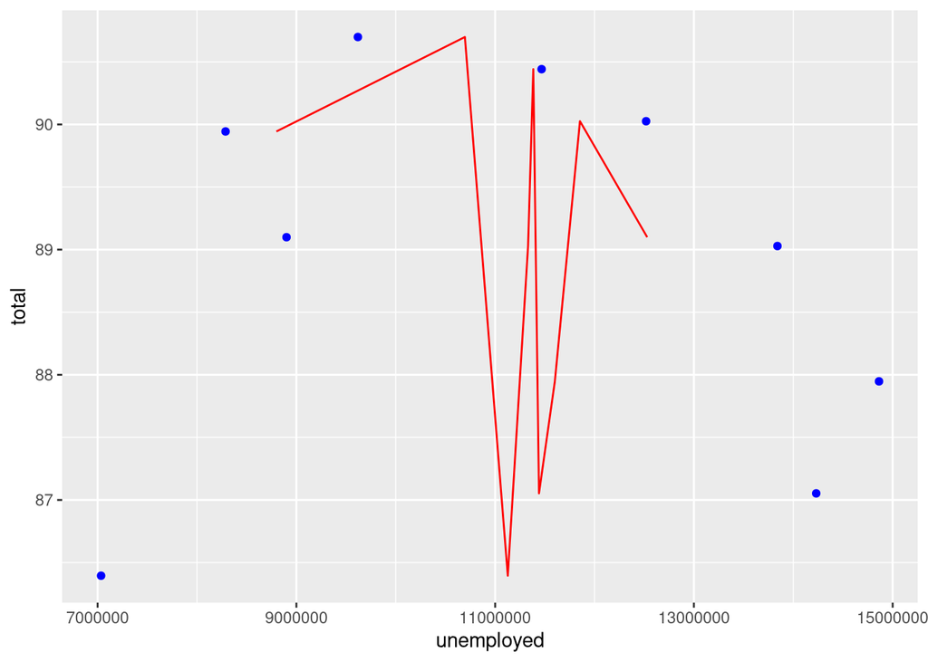

```r
hs_predict <- data.frame(hs_drug_predict=predict(corr_set1, hs_combined_dataset), hs_grad=hs_combined_dataset$total)
ggplot(data=hs_combined_dataset, aes(x=unemployed,y=total)) + geom_point(color='blue') + geom_line(color='red', data = hs_predict, aes(x=hs_drug_predict, y=hs_grad))
```

## Associates :

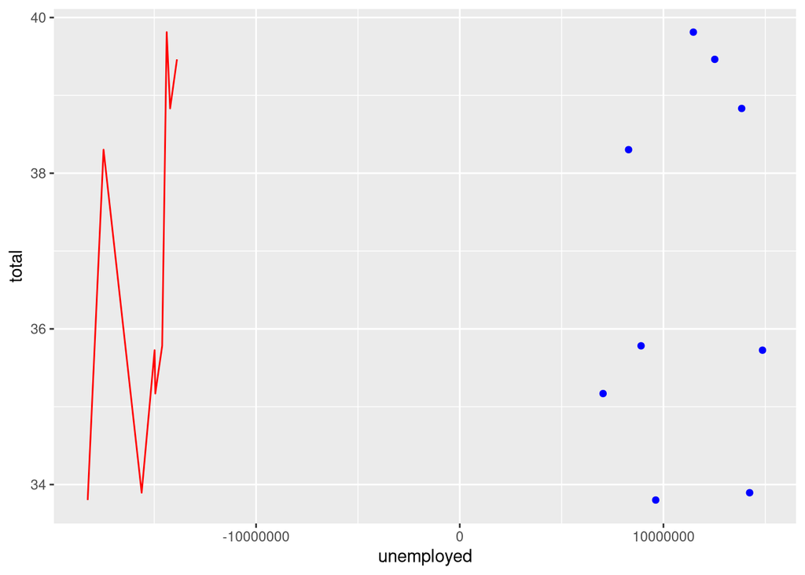

```r
aa_predict <- data.frame(aa_drug_predict=predict(corr_set1, aa_combined_dataset), aa_grad=aa_combined_dataset$total)
ggplot(data=aa_combined_dataset, aes(x=unemployed,y=total)) + geom_point(color='blue') + geom_line(color='red', data = aa_predict, aes(x=aa_drug_predict, y=aa_grad))
```

## Bachleors :

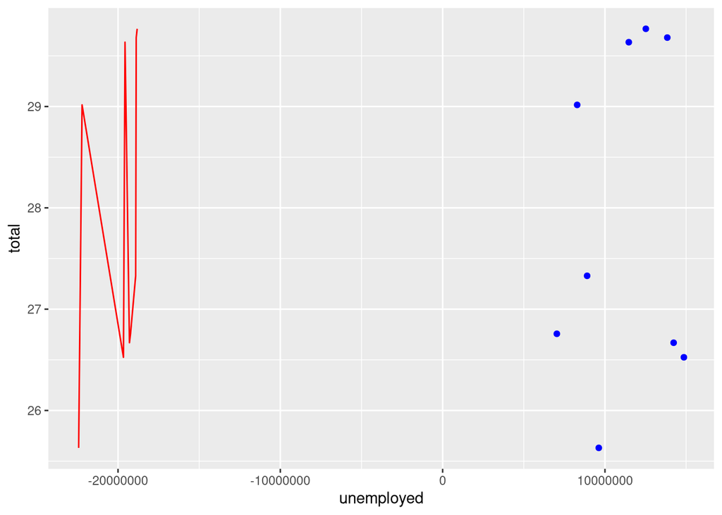

```r
ba_predict <- data.frame(ba_drug_predict=predict(corr_set1, ba_combined_dataset), ba_grad=ba_combined_dataset$total)
ggplot(data=ba_combined_dataset, aes(x=unemployed,y=total)) + geom_point(color='blue') + geom_line(color='red', data = ba_predict, aes(x=ba_drug_predict, y=ba_grad))
```

## Masters :

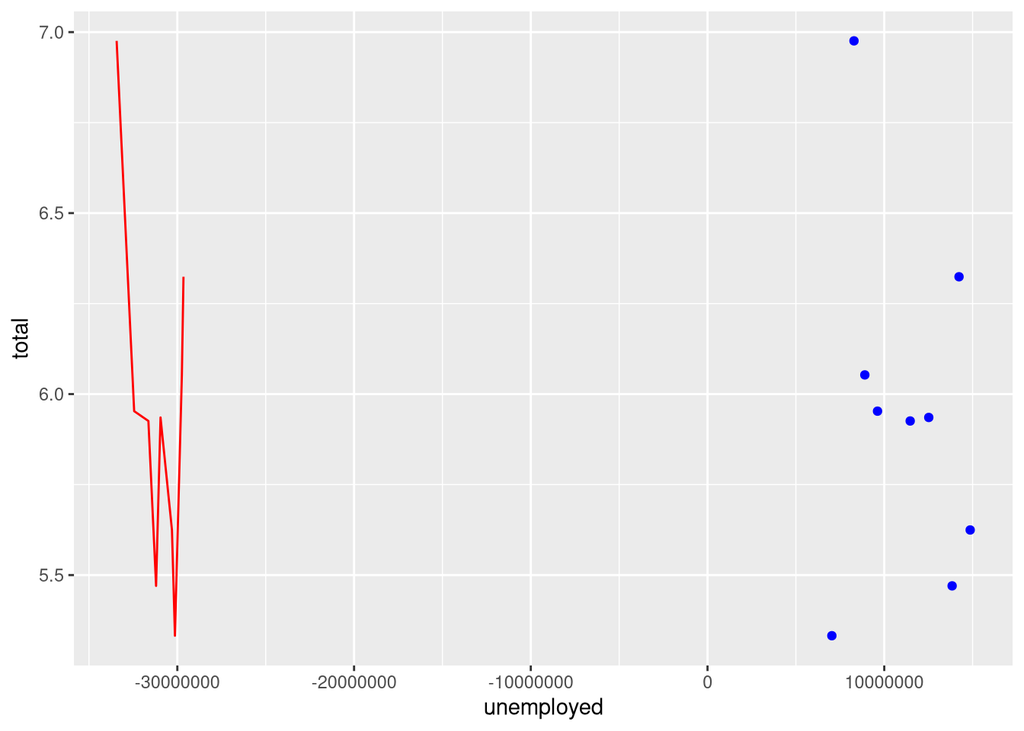

```r
ma_predict <- data.frame(ma_drug_predict=predict(corr_set1, ma_combined_dataset), ma_grad=ma_combined_dataset$total)
ggplot(data=ma_combined_dataset, aes(x=unemployed,y=total)) + geom_point(color='blue') + geom_line(color='red', data = ma_predict, aes(x=ma_drug_predict, y=ma_grad))
```

## Operationalization :

After ten years, we would be able to see a generation who grew up from teenagers into adults without the pressure of having to apply for scholarships, or work during college and we could follow through with the amount of drug deaths (not use, because responsible use of stimulants or depressents have been a part of society forever and any prohibition of it has always failed) that follow the concurrent generations and address the educational benefits or the adjustment of further study to see what other confounding factors arise.